# R training - Session 4

Fiona Warren, Laura Roldan Gomez

30/09/22

# 1 *Previously on R Workshops* : topics covered in the last section

In R Workshop 3, we…:

- … Learn how to explore your data: how to subset data parts, matching elements, merging and binding your data
- … Data manipulations: how to use the paste() function, rename your elements, use the seq() function
- … Basic visualisation: type of plots and how to make them, how to plot on top of plots, add to your plot, manipulate margins, composite plots and exporting your plots

If many of these learning outcomes sound unfamiliar, you may want to consider doing R Workshop 3 before today’s workshop.

# 2 Learning outcomes

**Today you will learn about:**

On completion of this session you should be able to:

- Import a dataset in csv format into R, assign it to a dataframe and explore the data
- Use descriptive statistics to describe numeric and categorical variables
- Use the normal distribution defined by the mean and standard deviation to find specified statistics, and test a continuous variable for normality
- Find confidence intervals for the mean of a continuous variable
- Perform random sampling from a dataset or from a defined distribution
- Visualise a dataset graphically using appropriate plots
- Explore relationships between variables, including use of inferential analyses.

# 3 Set-up

To start, set your chosen working directory using the ‘setwd’ command, or alternatively using the menu: Session>Set Working Directory>Choose Directory.

# 4 Data

We will use a dataset called `bp_dataset`, provided as a csv file. The dataset is based on a clinical trial to test the effect of two drugs (Drug A and Drug B), compared with an inactive control drug (placebo), on blood pressure in people who have high blood pressure. The purpose of the drugs is to reduce blood pressure. Some additional information about the people in the trial, such as their age and sex, is also provided (see codebook for further information about the variables).

Let’s start by loading the dataset. You need to ensure that the dataset is located in your working directory (Section 3). Read in the csv file and assign it to a dataframe: we will call the dataframe `bp_dataset`. The ‘header’ argument allows us to set the column headings as variable names when set to TRUE.

```r
bp_dataset<-read.csv(file="bp_dataset.csv", header=TRUE)
```

Take a look at the column heads.

```r
head(bp_dataset)
```

```
##   ptid male age intervention bp_baseline bp_3m bp_6m
## 1    1    1  41       Drug B         218   153   163
## 2    2    0  46       Drug B         200   162   177
## 3    3    0  37       Drug A         198   122   166
## 4    4    0  46       Drug A         202   148   128
## 5    5    1  44      Control         142   196   231
## 6    6    1  36       Drug B         148   191   164
```

Let’s find out how many rows (observations) and variables (columns) are in this dataset.

```r
nrow(bp_dataset)
```

```
## [1] 100
```

```r
ncol(bp_dataset)
```

```
## [1] 7
```

You can also use the ‘dim’ command (for dimensions), outputting number of rows and number of columns.

```r
dim(bp_dataset)
```

```
## [1] 100   7
```

We need to check the types of variable in the dataframe. Remember there are 5 main data types in R:

- character
- numeric
- integer
- logical
- complex

In this session, we are only considering character, numeric, integer and logical. Character variables may also be known as text or string variables.

In this dataset we have both integer and character variables (see the code snippet below). The variable `male` is an integer coded as 0 and 1, but could also be a character variable i.e. recorded as “Male”, “Female”. The variable `intervention` is a character variable, but could be an integer coded, for example, as Control=0, Drug A=1, Drug B=2.

The ‘str’ command allows us to check the structure of the dataframe.

```r
str(bp_dataset)
```

```
## 'data.frame':    100 obs. of  7 variables:
##  $ ptid        : int  1 2 3 4 5 6 7 8 9 10 ...
##  $ male        : int  1 0 0 0 1 1 0 0 1 1 ...
##  $ age         : int  41 46 37 46 44 36 65 69 58 65 ...
##  $ intervention: chr  "Drug B" "Drug B" "Drug A" "Drug A" ...
##  $ bp_baseline : int  218 200 198 202 142 148 166 201 206 140 ...
##  $ bp_3m       : int  153 162 122 148 196 191 140 141 173 125 ...
##  $ bp_6m       : int  163 177 166 128 231 164 152 113 164 115 ...
```

# 5 Topics

## 5.1 Basic statistics

From the dataset, there are 4 variables that include numeric data, that is, the information is an actual number rather than using numbers as codes. These are `age`, and blood pressure measured at three timepoints (`bp_baseline`, `bp_3m`, `bp_6m`).

We want to find the mean, median, standard deviation and variance for these variables. Let’s start with the mean. To find the mean for `age` we can use:

```r
mean(bp_dataset$age)
```

```
## [1] 49.03
```

We can attach the dataframe `bp_dataset`, so we don’t need to use the $ notation for each command. Remember to use the ‘detach’ command when you wish to detach the dataframe.

```r
attach(bp_dataset)

mean(age)
```

```
## [1] 49.03
```

#### 5.1.0.1 Task 1

Find the means for `bp_baseline` and `bp_3m`.

```r
mean(bp_baseline)
```

```
## [1] 182.4
```

```r
mean(bp_3m)
```

```
## [1] 165.88
```

We can summarise for different subsets of the data by using R command ‘tapply’. The ‘tapply’ command takes 3 arguments in the below command:

- `age`: numeric variable for which we wish to calculate the mean
- `male`: variable indicating the subgroups, in this case 0 and 1
- mean: the statistic we wish to calculate

```r
tapply(age, male, mean)
```

```
##        0        1
## 51.94595 47.31746
```

We can also use the code below. This calculates the mean for males [male==1]. Remember to use == to set the value of the variable `male` to be equal to 1.

```r
mean(age[male==1])
```

```
## [1] 47.31746
```

We can do the same for intervention group.

```r
tapply(age, intervention, mean)
```

```
##  Control   Drug A   Drug B
## 51.42857 50.61765 45.84211
```

Let’s say we want to calculate the mean age by sex and intervention group. We can use the ‘aggregate’ command. The FUN argument means function, which is the mean in this example.

```r
aggregate(age ~ male + intervention, data=bp_dataset, FUN=mean)
```

```
##   male intervention      age
## 1    0      Control 53.84615
## 2    1      Control 49.33333
## 3    0       Drug A 56.63636
## 4    1       Drug A 47.73913
## 5    0       Drug B 46.07692
## 6    1       Drug B 45.72000
```

We can also calculate the median, standard deviation, variance, minimum, maximum, range and sum.  
*Note* The commands ‘sd’ and ‘var’ calculate the sample sd and variance, not the population sd and variance.

```r
sd(age)
```

```
## [1] 12.31116
```

```r
median(age)
```

```
## [1] 47
```

```r
var(age)
```

```
## [1] 151.5647
```

```r
min(age)
```

```
## [1] 26
```

```r
max(age)
```

```
## [1] 81
```

```r
range(age)
```

```
## [1] 26 81
```

```r
sum(age)
```

```
## [1] 4903
```

We can also calculate percentiles. Using the ‘quantile’ command we can set the quantiles that we wish to find. Note that the 0.5 quantile is the median.

```r
quantile(age, probs = c(.25, .5, .75))
```

```
##   25%   50%   75%
## 40.00 47.00 56.25
```

To get the inter-quartile range (75th percentile minus 25th percentile):

```r
IQR(age)
```

```
## [1] 16.25
```

#### 5.1.0.2 Task 2

```r
tapply(bp_baseline, intervention, mean)
```

```
##  Control   Drug A   Drug B
## 174.6786 181.2647 189.1053
```

```r
tapply(bp_baseline, intervention, sd)
```

```
##  Control   Drug A   Drug B
## 22.45333 24.26659 25.46093
```

```r
tapply(bp_baseline, intervention, median)
```

```
## Control  Drug A  Drug B
##   171.0   185.5   188.5
```

```r
aggregate(age ~ male + intervention, data=bp_dataset,
          FUN=quantile,(probs=c(.25, .5, .75)))
```

```
##   male intervention age.25% age.50% age.75%
## 1    0      Control    42.0    52.0    65.0
## 2    1      Control    44.0    48.0    55.5
## 3    0       Drug A    46.5    53.0    68.0
## 4    1       Drug A    40.5    48.0    53.5
## 5    0       Drug B    38.0    42.0    48.0
## 6    1       Drug B    39.0    43.0    49.0
```

We can create a frequency table for categorical variables using the ‘table’ command.

```r
table(male)
```

```
## male
##  0  1
## 37 63
```

If we also wish to calculate proportions or percentages, we can use the ‘prop.table’ command. We first need to create the table and then pass to ‘prop.table’.

```r
table.male<-table(male)

prop.table(table.male)
```

```
## male
##    0    1
## 0.37 0.63
```

We can also create a table for a subgroup of the data. For example: table by sex for people aged over 50.

```r
table(male[age>50])
```

```
##
##  0  1
## 17 19
```

```r
table.male.over50<-table(male[age>49])

prop.table(table.male.over50)
```

```
##
##    0    1
## 0.45 0.55
```

We can also produce cross-tabulations for two categorical variables.

```r
table(male, intervention)
```

```
##     intervention
## male Control Drug A Drug B
##    0      13     11     13
##    1      15     23     25
```

```r
table.male.intervention<-table(male, intervention)

prop.table(table.male.intervention)
```

```
##     intervention
## male Control Drug A Drug B
##    0    0.13   0.11   0.13
##    1    0.15   0.23   0.25
```

#### 5.1.0.3 Task 3

Create table of frequencies and a table of percentages by intervention group.

```r
table(intervention)
```

```
## intervention
## Control  Drug A  Drug B
##      28      34      38
```

```r
table.intervention<-table(intervention)

prop.table(table.intervention)
```

```
## intervention
## Control  Drug A  Drug B
##    0.28    0.34    0.38
```

#### 5.1.0.4 Task 4

Create table of frequencies and a table of percentages by intervention group for people whose baseline blood pressure is greater than or equal to 180.

```r
table.intervention.bp180plus<-table(intervention[bp_baseline>=180])

prop.table(table.intervention.bp180plus)
```

```
##
##   Control    Drug A    Drug B
## 0.1764706 0.3725490 0.4509804
```

## 5.2 Normal distribution

We can use R to get the cumulative density function (cdf) of a given normal distribution, based on the mean and sd. For example, to find the proportion of people with blood pressure less than 80, assuming mean BP=112 and SD is 15, we can use the ‘pnorm’ command.

```r
pnorm(80, mean=112, sd=15)
```

```
## [1] 0.0164487
```

To find the proportion of people with BP above 125 we can use the code below.  
*Note* The argument lower.tail=FALSE tells the pnorm function to return the value to the right of the given value.

```r
pnorm(125, mean=112, sd=15, lower.tail=FALSE)
```

```
## [1] 0.1930623
```

The same result can be obtained by using the command ‘1-pnorm’.

```r
1-pnorm(125, mean=112, sd=15)
```

```
## [1] 0.1930623
```

The command ‘qnorm’ gives the inverse of the cdf (i.e. Z-score for the associated quantile). For example, for quantiles of the standard normal distribution (mean=0, sd=1) Z-score for 95th quantile:

```r
qnorm(0.95, mean=0, sd=1)
```

```
## [1] 1.644854
```

Z-score for 10th quantile:

```r
qnorm(0.1, mean=0, sd=1)
```

```
## [1] -1.281552
```

#### 5.2.0.1 Task 5

Using the mean and sd for `age`, find the quantile for the 5th quantile and 97.5th quantile, assuming the distribution of `age` to be normal. Use values to 1 decimal place.

```r
mean(age)
```

```
## [1] 49.03
```

```r
sd(age)
```

```
## [1] 12.31116
```

```r
qnorm(0.05, mean=49.0, sd=12.3)
```

```
## [1] 28.7683
```

```r
qnorm(0.975, mean=49.0, sd=12.3)
```

```
## [1] 73.10756
```

#### 5.2.0.2 Task 6

Find the probability that a member of the sample is aged under 35 and the probability that a member of the sample is aged over 60.

```r
pnorm(35, mean=49.0, sd=12.3)
```

```
## [1] 0.1275161
```

```r
pnorm(60, mean=49.0, sd=12.3, lower.tail=FALSE)
```

```
## [1] 0.1855783
```

#### 5.2.0.3 Task 7

Find the probability that a member of the sample is aged between 50 and 55.

```r
pnorm(55, mean=49.0, sd=12.3) -
  pnorm(50, mean=49.0, sd=12.3)
```

```
## [1] 0.1547573
```

## 5.3 Confidence intervals

You will need to install package ‘Rmisc’ for this section.

**2-sided confidence interval**  
We will start by calculating a 2-sided 95% confidence interval for a mean, using the `age` variable. The command ‘CI’ is used. The 95% CI is the most common certainty level used: this is indicated by the ‘ci’ argument.

```r
CI(age, ci=0.95)
```

```
##   upper    mean   lower
## 51.4728 49.0300 46.5872
```

For a 2-sided 99% CI:

```r
CI(age, ci=0.99)
```

```
##    upper     mean    lower
## 52.26341 49.03000 45.79659
```

**One-sided CI**  
For a one-sided CI, calculate the two-sided CI that corresponds to the required upper or lower bound. For example, for a lower 80% CI, calculate the 60% CI and take upper bound.

```r
CI(age, ci=0.60)
```

```
##    upper     mean    lower
## 50.07062 49.03000 47.98938
```

#### 5.3.0.1 Task 8

Calculate the 2-sided 80% and 90% CI for `bp_baseline`.

```r
CI(bp_baseline, ci=0.80)
```

```
##    upper     mean    lower
## 185.5881 182.4000 179.2119
```

```r
CI(bp_baseline, ci=0.90)
```

```
##   upper    mean   lower
## 186.503 182.400 178.297
```

Calculate the 1-sided lower 97.5th% CI for `bp_baseline`.

```r
CI(bp_baseline, ci=0.95)
```

```
##    upper     mean    lower
## 187.3032 182.4000 177.4968
```

**CI for subgroups**  
For example, to calculate the 90% CI for `age` by sex:

```r
group.CI(age~male,data=bp_dataset, ci=0.90)
```

```
##   male age.upper age.mean age.lower
## 1    0  55.76390 51.94595  48.12799
## 2    1  49.66096 47.31746  44.97396
```

#### 5.3.0.2 Task 9

Calculate the 95% CI for baseline BP for each intervention group.

```r
group.CI(bp_baseline~intervention ,data=bp_dataset, ci=0.95)
```

```
##   intervention bp_baseline.upper bp_baseline.mean bp_baseline.lower
## 1      Control          183.3851         174.6786          165.9721
## 2       Drug A          189.7317         181.2647          172.7977
## 3       Drug B          197.4741         189.1053          180.7365
```

## 5.4 Random sampling

### 5.4.1 Sampling from a dataset

We may sometimes wish to randomly select a subset of participants from a dataset. We can use the ‘sample’ function in R.

To select 5 rows from our dataframe `bp_dataset`:

```r
bp_dataset[sample(nrow(bp_dataset), 5), ]
```

```
##    ptid male age intervention bp_baseline bp_3m bp_6m
## 31   31    1  31       Drug A         186   164   135
## 44   44    1  53       Drug A         213   167   130
## 46   46    1  47       Drug B         177   184   173
## 49   49    1  45       Drug A         164   132   116
## 53   53    1  52       Drug A         187   148   144
```

Alternatively, we can use the ‘sample_n’ function from the ‘dplyr’ package. Ensure that the ‘dplyr’ package is installed.

```r
install.packages("dplyr")
library(dplyr)
```

To select 10 rows from our dataframe `bp_dataset`:

```r
sample_n(bp_dataset, 10)
```

```
##    ptid male age intervention bp_baseline bp_3m bp_6m
## 1    87    0  75       Drug A         195   139   119
## 2    59    0  42       Drug B         214   164   179
## 3     2    0  46       Drug B         200   162   177
## 4    32    0  39       Drug B         168   172   167
## 5    38    1  43       Drug B         147   169   159
## 6     4    0  46       Drug A         202   148   128
## 7    70    0  40      Control         153   220   188
## 8     1    1  41       Drug B         218   153   163
## 9    13    1  54       Drug A         177   149   148
## 10   53    1  52       Drug A         187   148   144
```

We may also wish to generate a random sample of numbers from a specific distribution.

To simulate 5 numbers from a uniform distribution between 0 and 1:

```r
runif(5,0,1)
```

```
## [1] 0.67887523 0.36388035 0.98919966 0.07308645 0.56859038
```

To simulate 10 numbers from a normal distribution with mean =0 and SD =5:

```r
rnorm (10, mean = 0, sd = 5)
```

```
##  [1] -0.5226447 -3.4601028  2.0191917 -3.0713233  4.4258995  5.3138768
##  [7]  0.3625148 -0.1828069  1.3567016  7.0279121
```

To simulate Bernoulli/binomial trials:

rbinom ( observations, trials per observation, probability of success for each trial)

For a single observation of one Bernoulli trial, p(success)=0.2:

```r
rbinom(1, 1, 0.2)
```

```
## [1] 0
```

For five observations of one Bernoulli trial, p(success)=0.7:

```r
rbinom(5, 1, 0.7)
```

```
## [1] 1 0 0 0 0
```

For one observation of a binomial distribution, 10 trials, p(success=0.8):

```r
rbinom(1, 10, 0.8)
```

```
## [1] 7
```

The number of successes (out of a maximum of 10) is returned.

For 5 observations of a binomial distribution, 20 trials, p(success=0.25):

```r
rbinom(5, 20, 0.25)
```

```
## [1] 3 4 9 6 7
```

The number of successes (out of a maximum of 20) for each observation is returned.

#### 5.4.1.1 Task 10

```r
rbinom(5, 10, 0.6)
```

```
## [1] 7 6 6 3 8
```

## 5.5 Normality testing

Prior to performing statistical tests that are based on the assumption of a normally distributed variable, we wish to test the assumption of normality. One way to do this is with a histogram.  
Basic syntax: hist (v, main, xlab, xlim, ylim, breaks,col,border)  
`v` is the variable that is being plotted.

As an example, we can create a histogram of `age`.

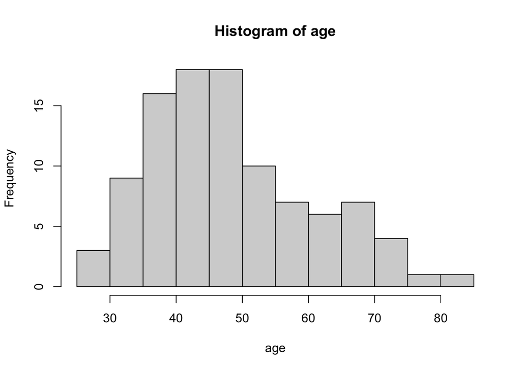

```r
hist(age)
```

We can add a title (main), x-axis label (xlab), set limitations to the axes (xlim, ylim), set the number of bins (breaks), and colours for the columns and borders.

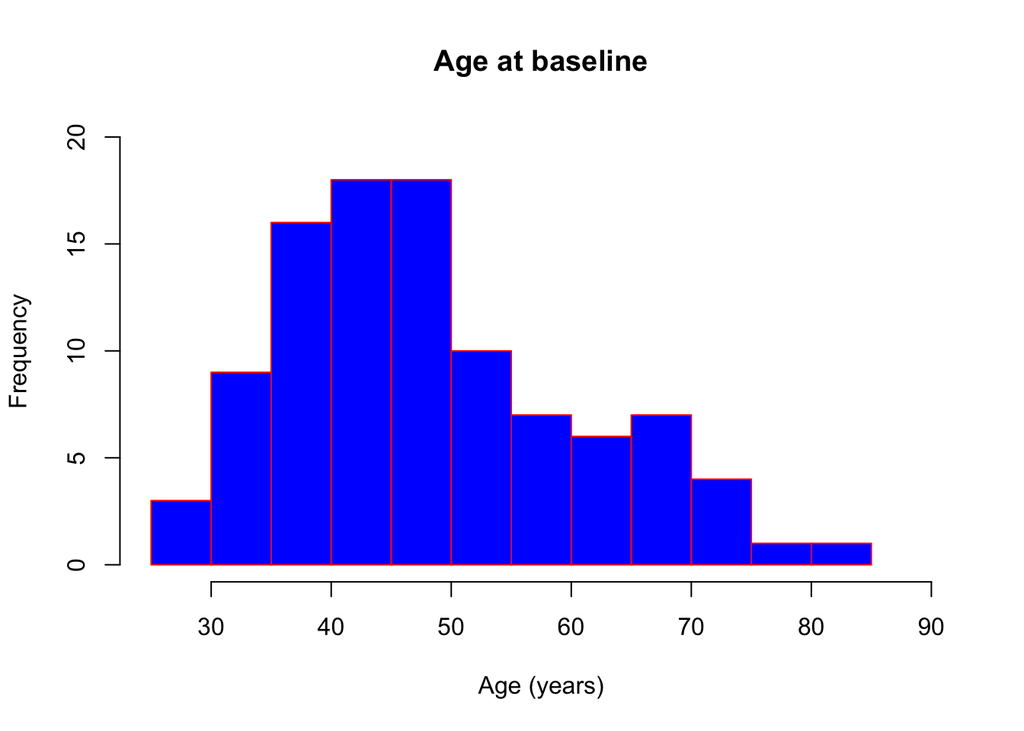

```r
hist(age, main="Age at baseline",
     xlab="Age (years)",
     xlim=c(25,90),
     ylim=c(0,20),
     breaks=15,
     col="blue",
     border="red")
```

We can also get details about the histogram, e.g. bin boundaries, number of observations in each bin.

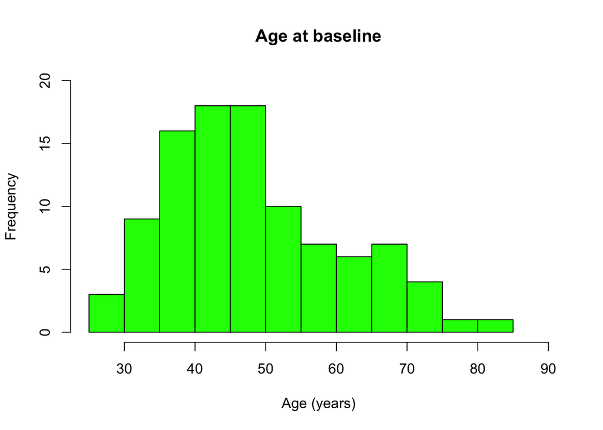

```r
hage<-hist(age, main="Age at baseline",
     xlab="Age (years)",
     xlim=c(25,90),
     ylim=c(0,20),
     breaks=15,
     col="green",
     border="black")
```

```r
hage
```

```
## $breaks
##  [1] 25 30 35 40 45 50 55 60 65 70 75 80 85
##
## $counts
##  [1]  3  9 16 18 18 10  7  6  7  4  1  1
##
## $density
##  [1] 0.006 0.018 0.032 0.036 0.036 0.020 0.014 0.012 0.014 0.008 0.002 0.002
##
## $mids
##  [1] 27.5 32.5 37.5 42.5 47.5 52.5 57.5 62.5 67.5 72.5 77.5 82.5
##
## $xname
## [1] "age"
##
## $equidist
## [1] TRUE
##
## attr(,"class")
## [1] "histogram"
```

To get just the bin boundaries:

```r
hage$breaks
```

```
##  [1] 25 30 35 40 45 50 55 60 65 70 75 80 85
```

We can also add a normal curve.

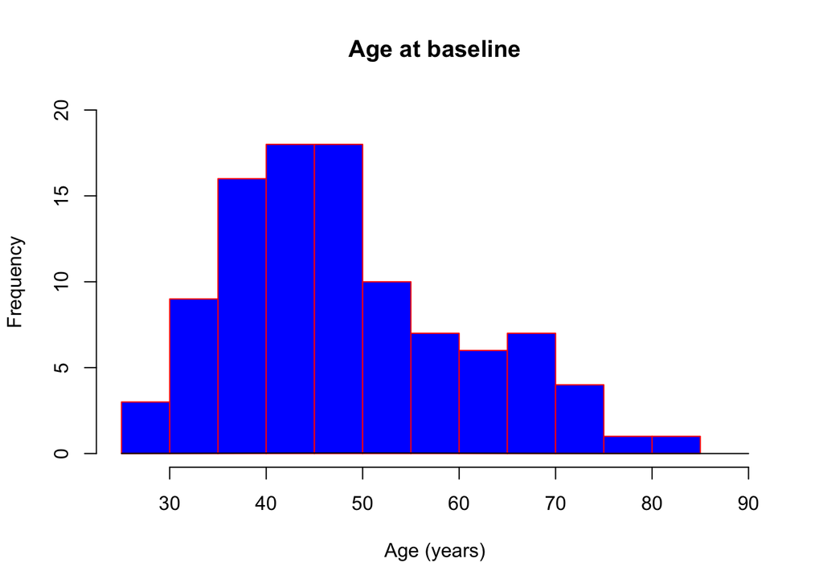

```r
hist(age, main="Age at baseline",
     xlab="Age (years)",
     xlim=c(25,90),
     ylim=c(0,20),
     breaks=15,
     col="blue",
     border="red")
curve (dnorm(x, mean=mean(age), sd=sd(age)), add=TRUE, col="black")
```

We can also add a line to show the density of `age`.

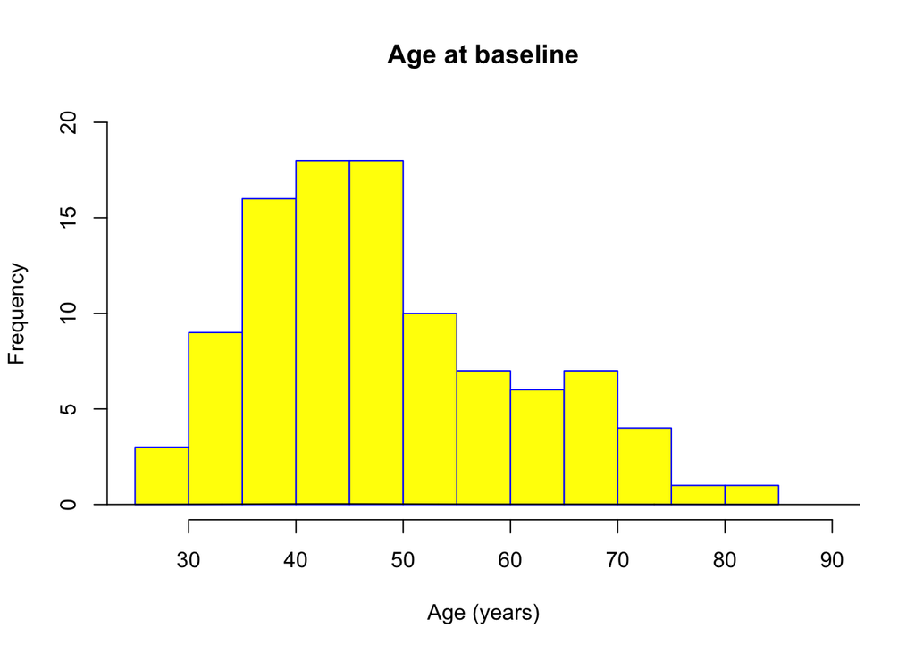

```r
hist(age, main="Age at baseline",
     xlab="Age (years)",
     xlim=c(25,90),
     ylim=c(0,20),
     breaks=15,
     col="yellow",
     border="blue")
lines(density(age), add=TRUE)
```

We can also create overlapping histograms for subgroups using ‘ggplot’. You need to make sure package ‘ggplot2’ is installed.

```r
install.packages("ggplot2")
library(ggplot2)
```

Website for colours in R  
https://r-charts.com/colors/

To change fill and outline color manually:

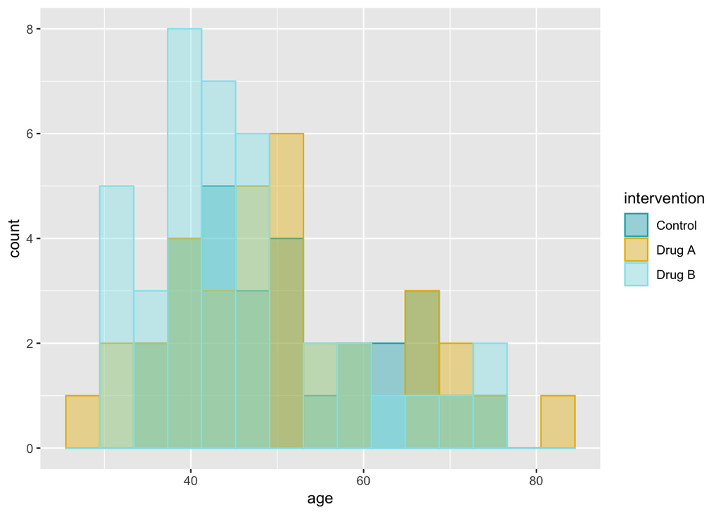

```r
ggplot(bp_dataset, aes(x = age)) +
  geom_histogram(aes(color = intervention, fill = intervention),
                 position = "identity", bins = 15, alpha = 0.4) +
  scale_color_manual(values = c("#00AFBB", "#E7B800", "#8EE5EE")) +
  scale_fill_manual(values = c("#00AFBB", "#E7B800", "#8EE5EE"))
```

We can also create a histogram by sex if we create a factor variable using the variable `male`, which is coded as 0 and 1.

```r
male_factor<-factor(male)

class(male_factor)
```

```
## [1] "factor"
```

```r
levels(male_factor)
```

```
## [1] "0" "1"
```

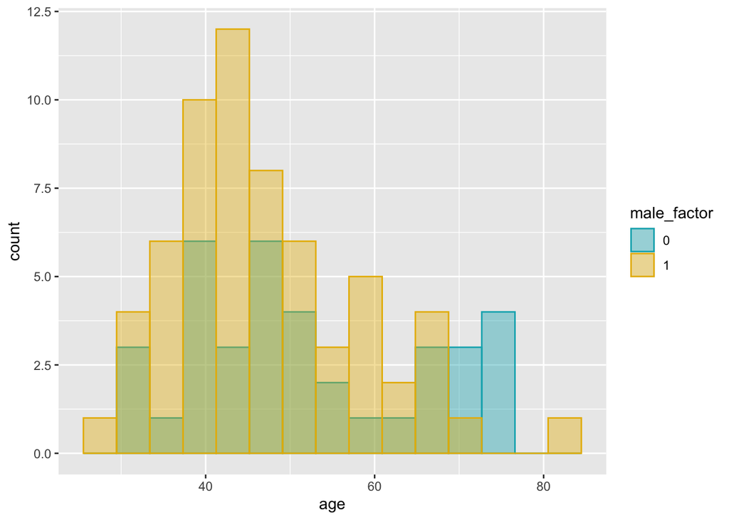

```r
ggplot(bp_dataset, aes(x = age)) +
  geom_histogram(aes(color = male_factor, fill = male_factor),
                 position = "identity", bins = 15, alpha = 0.4) +
  scale_color_manual(values = c("#00AFBB", "#E7B800")) +
  scale_fill_manual(values = c("#00AFBB", "#E7B800"))
```

We can also create separate histograms for different subgroups. It is necessary to use the `male` variable coded as 0 and 1 for this command.

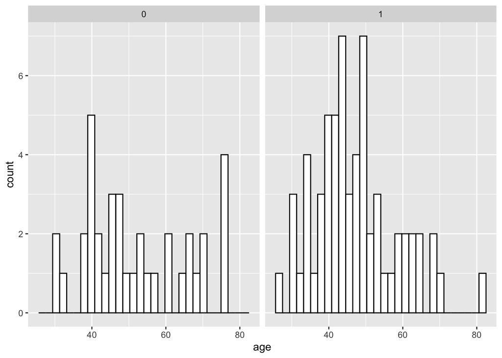

```r
ggplot(bp_dataset, aes(x = age)) +
  geom_histogram(fill = "white", colour = "black") +
  facet_wrap(~male)
```

We can also use a boxplot.

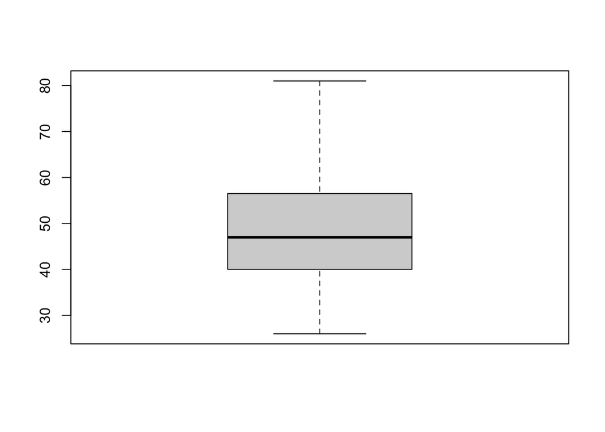

```r
boxplot(age)
```

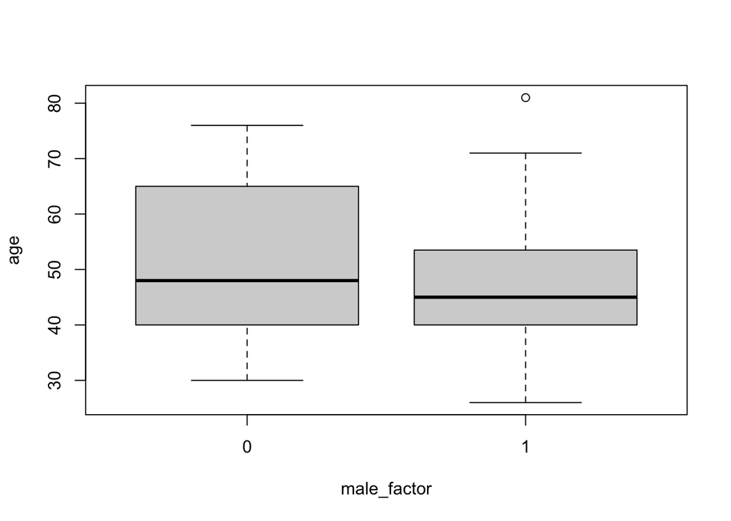

```r
boxplot(age ~ male_factor)
```

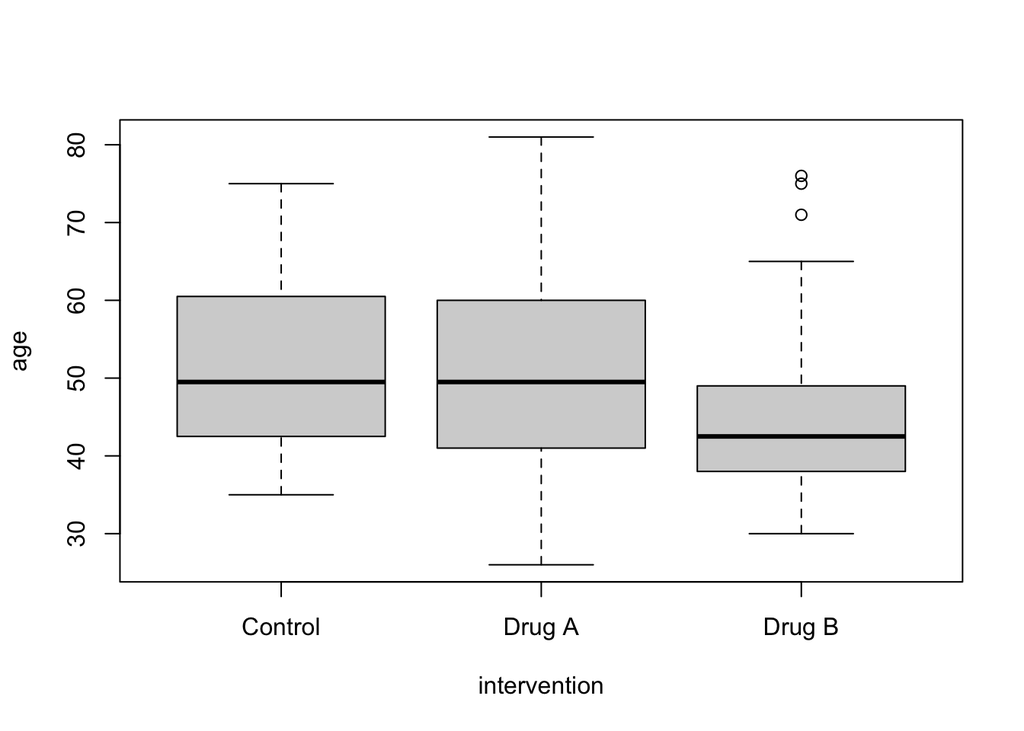

```r
boxplot(age ~ intervention)
```

For different colours use:

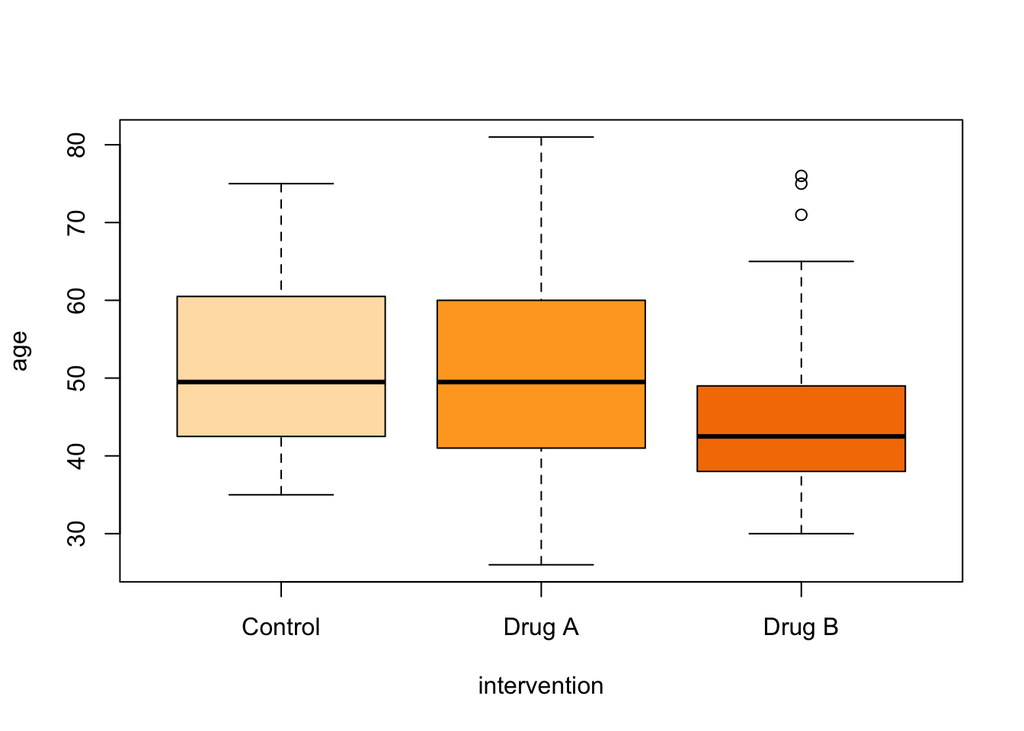

```r
boxplot(age ~ intervention,
        col = c("#FFE0B2", "#FFA726", "#F57C00"))
```

We can also perform a Shapiro-Wilk test for normality.

```r
shapiro.test(age)
```

```
##
##  Shapiro-Wilk normality test
##
## data:  age
## W = 0.959, p-value = 0.003415
```

#### 5.5.0.1 Task 11

Create a histogram for `bp_baseline` and perform a Shapiro-Wilk test for normality.

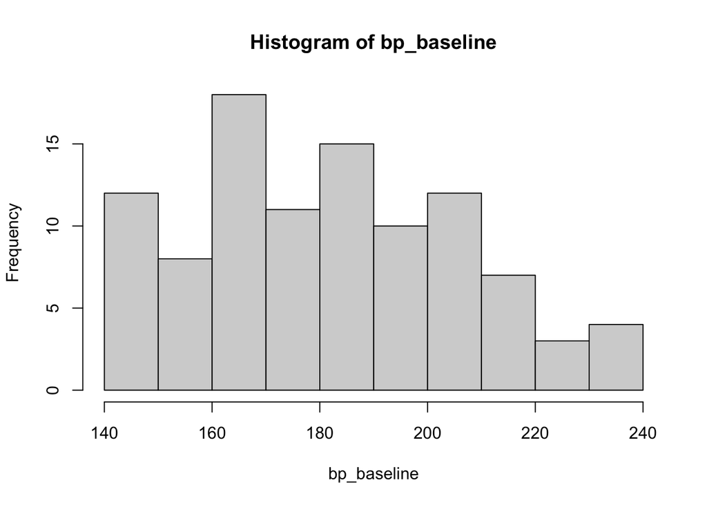

```r
hist(bp_baseline)
```

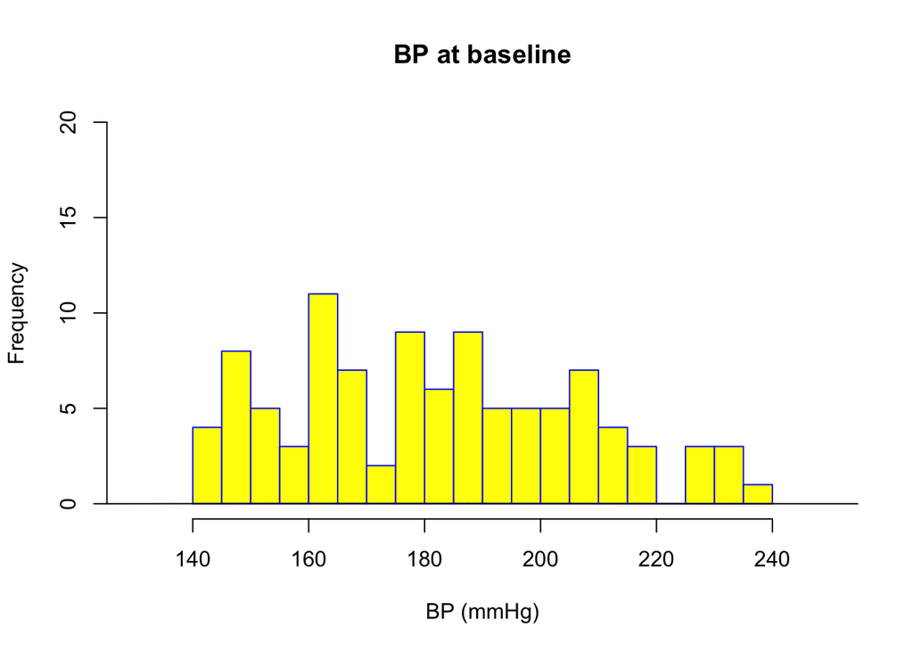

```r
hist(bp_baseline, main="BP at baseline",
     xlab="BP (mmHg)",
     xlim=c(130,250),
     ylim=c(0,20),
     breaks=15,
     col="yellow",
     border="blue")
lines(density(bp_baseline), add=TRUE)
```

#### 5.5.0.2 Task 12

Create histograms for baseline BP by sex (either overlapping or on separate plots).

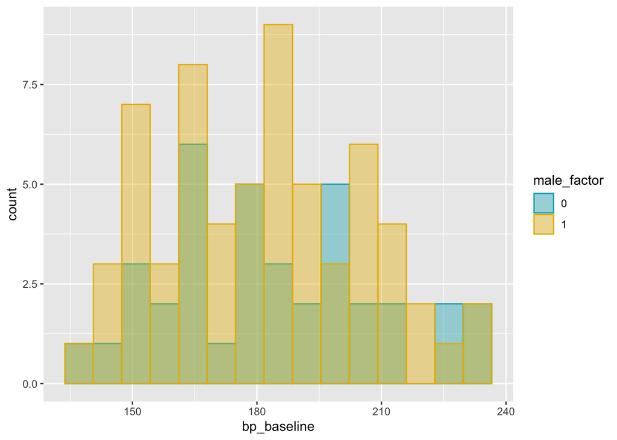

```r
ggplot(bp_dataset, aes(x = bp_baseline)) +
  geom_histogram(aes(color = male_factor, fill = male_factor),
                 position = "identity", bins = 15, alpha = 0.4) +
  scale_color_manual(values = c("#00AFBB", "#E7B800")) +
  scale_fill_manual(values = c("#00AFBB", "#E7B800"))
```

#### 5.5.0.3 Task 13

Perform a Shapiro-Wilk test for normality for baseline BP.

```r
shapiro.test(bp_baseline)
```

```
##
##  Shapiro-Wilk normality test
##
## data:  bp_baseline
## W = 0.97272, p-value = 0.03581
```

## 5.6 Correlation

Before we perform a correlation test we can create a scatterplot to check the relationship between variables. For example, to check the relationship between `age` and `bp_baseline`:

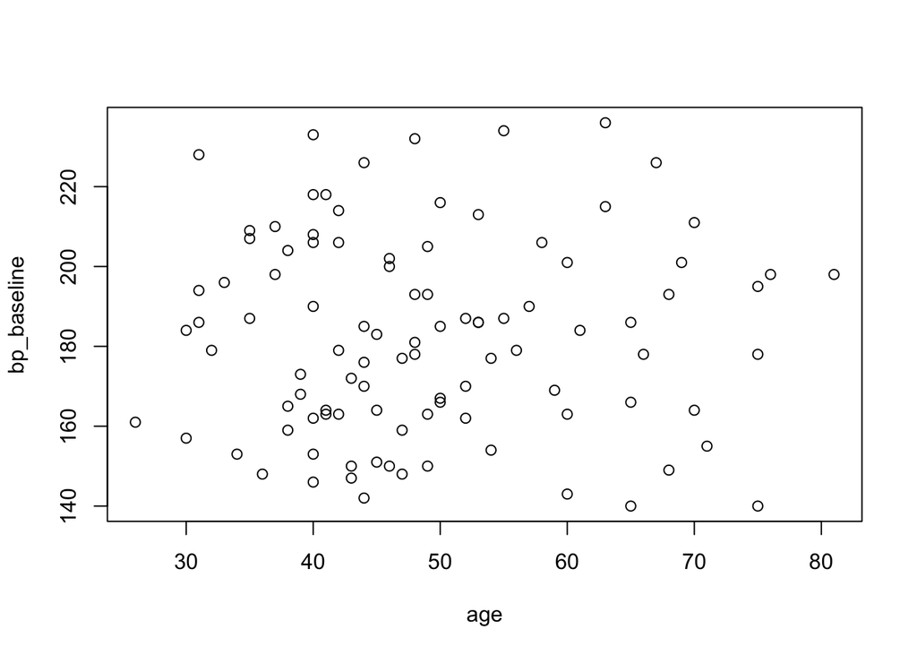

```r
plot(age, bp_baseline)
```

For a Pearson correlation, remember that variables should be distributed normally and with a linear relationship. The Pearson correlation is the default method for the ‘cor.test’ command. We can use ‘cor.test’ to find the Pearson correlation between `age` and `bp_baseline`

```r
cor.test(age, bp_baseline)
```

```
##
##  Pearson's product-moment correlation
##
## data:  age and bp_baseline
## t = 0.11268, df = 98, p-value = 0.9105
## alternative hypothesis: true correlation is not equal to 0
## 95 percent confidence interval:
##  -0.1854507  0.2073366
## sample estimates:
##        cor
## 0.01138201
```

For a Spearman correlation, we use `cor.test’ but change the ‘method’ argument:

```r
cor.test(age, bp_baseline, method="spearman")
```

```
##
##  Spearman's rank correlation rho
##
## data:  age and bp_baseline
## S = 165406, p-value = 0.9412
## alternative hypothesis: true rho is not equal to 0
## sample estimates:
##         rho
## 0.007464794
```

#### 5.6.0.1 Task 14

Calculate the Pearson and Spearman correlation between `bp_baseline` and `bp_3m`.

```r
cor.test(bp_baseline, bp_3m, method="pearson")
```

```
##
##  Pearson's product-moment correlation
##
## data:  bp_baseline and bp_3m
## t = -1.2932, df = 98, p-value = 0.199
## alternative hypothesis: true correlation is not equal to 0
## 95 percent confidence interval:
##  -0.31786629  0.06862855
## sample estimates:
##        cor
## -0.1295357
```

```r
cor.test(bp_baseline, bp_3m, method="spearman")
```

```
##
##  Spearman's rank correlation rho
##
## data:  bp_baseline and bp_3m
## S = 189628, p-value = 0.1713
## alternative hypothesis: true rho is not equal to 0
## sample estimates:
##        rho
## -0.1378832
```

## 5.7 T-test

#### 5.7.0.1 One-sample t-test

There are several types of t-test. We will start with the simplest: a one-sample 2-sided t-test to test the null hypothesis that the true mean is equal to a pre-specified value. For example, we can use a t-test to test if true mean `age`=50.

```r
t.test(age, mu=50)
```

```
##
##  One Sample t-test
##
## data:  age
## t = -0.7879, df = 99, p-value = 0.4326
## alternative hypothesis: true mean is not equal to 50
## 95 percent confidence interval:
##  46.5872 51.4728
## sample estimates:
## mean of x
##     49.03
```

t-test to test if true mean `age`=53:

```r
t.test(age, mu=53)
```

```
##
##  One Sample t-test
##
## data:  age
## t = -3.2247, df = 99, p-value = 0.001709
## alternative hypothesis: true mean is not equal to 53
## 95 percent confidence interval:
##  46.5872 51.4728
## sample estimates:
## mean of x
##     49.03
```

We can vary the width of the confidence interval provided as part of the t-test output - the default is 95% CI.

```r
t.test(age, mu=50, conf.level=0.90)
```

```
##
##  One Sample t-test
##
## data:  age
## t = -0.7879, df = 99, p-value = 0.4326
## alternative hypothesis: true mean is not equal to 50
## 90 percent confidence interval:
##  46.98587 51.07413
## sample estimates:
## mean of x
##     49.03
```

We can also specify the dataset and a subset of the data if needed. For example, in females only:

```r
female_only<-subset(bp_dataset, male==0)
head(female_only)
```

```
##    ptid male age intervention bp_baseline bp_3m bp_6m
## 2     2    0  46       Drug B         200   162   177
## 3     3    0  37       Drug A         198   122   166
## 4     4    0  46       Drug A         202   148   128
## 7     7    0  65      Control         166   140   152
## 8     8    0  69       Drug A         201   141   113
## 11   11    0  53       Drug A         186   107   122
```

```r
detach(bp_dataset)
```

```r
attach(female_only)
t.test(age, mu=50)
```

```
##
##  One Sample t-test
##
## data:  age
## t = 0.8605, df = 36, p-value = 0.3952
## alternative hypothesis: true mean is not equal to 50
## 95 percent confidence interval:
##  47.35957 56.53232
## sample estimates:
## mean of x
##  51.94595
```

```r
attach(bp_dataset)
```

We can also specify a 1-sided t-test looking for whether the true mean of the variable is greater than or less than the specified value. To test whether true mean `age` is less than 50:

```r
t.test(age, mu=50, alternative="less")
```

```
##
##  One Sample t-test
##
## data:  age
## t = -0.7879, df = 99, p-value = 0.2163
## alternative hypothesis: true mean is less than 50
## 95 percent confidence interval:
##      -Inf 51.07413
## sample estimates:
## mean of x
##     49.03
```

To test whether true mean `age` is greater than 45:

```r
t.test(age, mu=45, alternative="greater")
```

```
##
##  One Sample t-test
##
## data:  age
## t = 3.2735, df = 99, p-value = 0.000732
## alternative hypothesis: true mean is greater than 45
## 95 percent confidence interval:
##  46.98587      Inf
## sample estimates:
## mean of x
##     49.03
```

### 5.7.1 Two-sample unpaired t-test

In this example, we wish compare males and females for age, or in other words we wish to know whether the true mean `age` is equal for males and females.

*Note* This version of the t-test assumes unequal variance.

```r
t.test(age~male)
```

```
##
##  Welch Two Sample t-test
##
## data:  age by male
## t = 1.739, df = 63.594, p-value = 0.08687
## alternative hypothesis: true difference in means between group 0 and group 1 is not equal to 0
## 95 percent confidence interval:
##  -0.6891826  9.9461538
## sample estimates:
## mean in group 0 mean in group 1
##        51.94595        47.31746
```

We can also use a factor variable to indicate the two groups (i.e. as opposed to an integer variable with groups coded as numbers).

```r
t.test(age~male_factor)
```

```
##
##  Welch Two Sample t-test
##
## data:  age by male_factor
## t = 1.739, df = 63.594, p-value = 0.08687
## alternative hypothesis: true difference in means between group 0 and group 1 is not equal to 0
## 95 percent confidence interval:
##  -0.6891826  9.9461538
## sample estimates:
## mean in group 0 mean in group 1
##        51.94595        47.31746
```

We can test for equal variance by using an F test. To compare the variance of `age` by `male`:

```r
var.test(age ~ male)
```

```
##
##  F test to compare two variances
##
## data:  age by male
## F = 1.5248, num df = 36, denom df = 62, p-value = 0.1431
## alternative hypothesis: true ratio of variances is not equal to 1
## 95 percent confidence interval:
##  0.8663612 2.8110952
## sample estimates:
## ratio of variances
##           1.524841
```

An alternative is Bartlett’s test:

```r
bartlett.test(age ~ male)
```

```
##
##  Bartlett test of homogeneity of variances
##
## data:  age by male
## Bartlett's K-squared = 2.0664, df = 1, p-value = 0.1506
```

If we wish to repeat the t-test using the assumption of equal variance:

```r
t.test(age~male, var.equal=TRUE)
```

```
##
##  Two Sample t-test
##
## data:  age by male
## t = 1.8368, df = 98, p-value = 0.06927
## alternative hypothesis: true difference in means between group 0 and group 1 is not equal to 0
## 95 percent confidence interval:
##  -0.3721683  9.6291395
## sample estimates:
## mean in group 0 mean in group 1
##        51.94595        47.31746
```

### 5.7.2 Paired t-test: comparing pairs of matched values

A paired t-test is used to compare two variables that are matched or paired in some way, for examples, measurements made on the same person at two different times. For example, we may wish to perform a paired- t-test to test whether the true mean difference between BP at baseline (`bp_baseline`) and BP at 3 months (`bp_3m`), measured in the same person, is equal to 0.

```r
t.test(bp_3m,bp_baseline,paired=TRUE)
```

```
##
##  Paired t-test
##
## data:  bp_3m and bp_baseline
## t = -4.5608, df = 99, p-value = 1.462e-05
## alternative hypothesis: true mean difference is not equal to 0
## 95 percent confidence interval:
##  -23.707166  -9.332834
## sample estimates:
## mean difference
##          -16.52
```

Note that the results are different if we do not take into account the paired nature of the variables.

```r
t.test(bp_3m,bp_baseline,paired=FALSE)
```

```
##
##  Welch Two Sample t-test
##
## data:  bp_3m and bp_baseline
## t = -4.8468, df = 197.48, p-value = 2.534e-06
## alternative hypothesis: true difference in means is not equal to 0
## 95 percent confidence interval:
##  -23.241544  -9.798456
## sample estimates:
## mean of x mean of y
##    165.88    182.40
```

#### 5.7.2.1 Task 15

Perform a single sample 2-sided t-test to test whether the true mean of baseline BP is equal to 170.

```r
t.test(bp_baseline, mu=170)
```

```
##
##  One Sample t-test
##
## data:  bp_baseline
## t = 5.018, df = 99, p-value = 2.303e-06
## alternative hypothesis: true mean is not equal to 170
## 95 percent confidence interval:
##  177.4968 187.3032
## sample estimates:
## mean of x
##     182.4
```

Repeat for test of whether true mean of baseline BP is equal to 180.

```r
t.test(bp_baseline, mu=180)
```

```
##
##  One Sample t-test
##
## data:  bp_baseline
## t = 0.97123, df = 99, p-value = 0.3338
## alternative hypothesis: true mean is not equal to 180
## 95 percent confidence interval:
##  177.4968 187.3032
## sample estimates:
## mean of x
##     182.4
```

Repeat for a 1-sided t-test of whether true mean of baseline BP is greater than 185.

```r
t.test(bp_baseline, mu=185, alternative="greater")
```

```
##
##  One Sample t-test
##
## data:  bp_baseline
## t = -1.0522, df = 99, p-value = 0.8524
## alternative hypothesis: true mean is greater than 185
## 95 percent confidence interval:
##  178.297     Inf
## sample estimates:
## mean of x
##     182.4
```

#### 5.7.2.2 Task 16

Perform an unpaired t-test to compare mean BP at 3 months between Drug A and the control group. Hint: use the ! symbol to indicate a logical statement about intervention.

```r
t.test(bp_3m~intervention,
       subset=intervention!="Drug B")
```

```
##
##  Welch Two Sample t-test
##
## data:  bp_3m by intervention
## t = 4.5588, df = 47.231, p-value = 3.646e-05
## alternative hypothesis: true difference in means between group Control and group Drug A is not equal to 0
## 95 percent confidence interval:
##  14.53029 37.47812
## sample estimates:
## mean in group Control  mean in group Drug A
##              176.3571              150.3529
```

Do the same to compare mean BP at 3 months between Drug B vs control, and between Drug B vs Drug A.

```r
t.test(bp_3m~intervention,
       subset=intervention!="Drug A")
```

```
##
##  Welch Two Sample t-test
##
## data:  bp_3m by intervention
## t = 0.75098, df = 48.433, p-value = 0.4563
## alternative hypothesis: true difference in means between group Control and group Drug B is not equal to 0
## 95 percent confidence interval:
##  -7.21744 15.82646
## sample estimates:
## mean in group Control  mean in group Drug B
##              176.3571              172.0526
```

```r
t.test(bp_3m~intervention,
       subset=intervention!="Control")
```

```
##
##  Welch Two Sample t-test
##
## data:  bp_3m by intervention
## t = -4.9427, df = 69.884, p-value = 5.084e-06
## alternative hypothesis: true difference in means between group Drug A and group Drug B is not equal to 0
## 95 percent confidence interval:
##  -30.45604 -12.94334
## sample estimates:
## mean in group Drug A mean in group Drug B
##             150.3529             172.0526
```

#### 5.7.2.3 Task 17

Perform a paired t-test to test the null hypothesis that mean difference is 0 comparing BP at 6 months with BP at baseline.

```r
t.test(bp_6m,bp_baseline,paired=TRUE)
```

```
##
##  Paired t-test
##
## data:  bp_6m and bp_baseline
## t = -5.5298, df = 99, p-value = 2.613e-07
## alternative hypothesis: true mean difference is not equal to 0
## 95 percent confidence interval:
##  -29.39129 -13.86871
## sample estimates:
## mean difference
##          -21.63
```

Repeat to compare BP at 6 months with BP at 3 months for women (male=0) only.

```r
attach(female_only)
t.test(bp_6m,bp_3m,paired=TRUE)
```

```
##
##  Paired t-test
##
## data:  bp_6m and bp_3m
## t = -1.7174, df = 36, p-value = 0.09449
## alternative hypothesis: true mean difference is not equal to 0
## 95 percent confidence interval:
##  -13.792597   1.143949
## sample estimates:
## mean difference
##       -6.324324
```

```r
attach(bp_dataset)
```

## 5.8 ANOVA

We perform a one-way ANOVA (ANalysis Of VAriance test) to compare means across three or more groups. For example, to compare mean BP at 3 months across Drug A, Drug B, Control:

```r
oneway.drug <- aov(bp_3m ~ intervention)

summary(oneway.drug)
```

```
##              Df Sum Sq Mean Sq F value   Pr(>F)
## intervention  2  12718    6359   14.74 2.57e-06 ***
## Residuals    97  41840     431
## ---
## Signif. codes:  0 '***' 0.001 '**' 0.01 '*' 0.05 '.' 0.1 ' ' 1
```

#### 5.8.0.1 Task 18

Perform a one-way ANOVA to compare `age` across the three intervention groups.

```r
oneway.age<- aov(age~intervention)
summary(oneway.age)
```

```
##              Df Sum Sq Mean Sq F value Pr(>F)
## intervention  2    633   316.5   2.136  0.124
## Residuals    97  14372   148.2
```

# 6 Resources

- [Basic R cheat sheet](https://www.datasciencecentral.com/r-and-python-cheatsheets/)
- [Data Carpentry Introduction to R](https://datacarpentry.org/R-ecology-lesson/01-intro-to-r.html)
- [Software Carpentry: Programming with R.](https://github.com/swcarpentry/r-novice-inflammation)
- [R for Data Science](https://r4ds.had.co.nz)
- [ColorHexa](https://www.colorhexa.com/)
- [R Base Graphics Cheatsheet](http://publish.illinois.edu/johnrgallagher/files/2015/10/BaseGraphicsCheatsheet.pdf)
- [R colour charts](https://r-charts.com/colors/)

# 7 Acknowledgements

Inspired by and adopted from: John Blischak, Daniel Chen, Harriet Dashnow, and Denis Haine (eds): “Software Carpentry: Programming with R.” Version 2016.06, June 2016, https://github.com/swcarpentry/r-novice-inflammation, 10.5281/zenodo.57541. Jenny Bryan: https://jennybc.github.io/purrr-tutorial Manuel Gimond: https://mgimond.github.io/ES218/Week02a.html Damaris Zurell (Ecology & Macroecology Lab, Univ. Potsdam 2020-2022): https://damariszurell.github.io/EEC-R-prep/index.html

# 8 Licence

Licensed under [CC-BY 4.0](https://creativecommons.org/licenses/by/4.0/)